# week03_in_class

## Week 3

### Monday

**Note** on weekly summary, you need to use your ubit name (NOT your ub person number)

For loop vs while loop

```python
for k in range(501):
    do something
```

```
  File "<ipython-input-4-2bacc9e5de8c>", line 2
    do something
               ^
SyntaxError: invalid syntax
```

```python
while (something that is True): # iterate 'as long as'
    instructions
    update line
```

```
  File "<ipython-input-6-32a870291bca>", line 1
    while (something that is True): # iterate 'as long as'
                        ^
SyntaxError: invalid syntax
```

```python
for k in range(5):
    print(3**k)
```

```
1
3
9
27
81
```

```python
k=0
while k<5:
    print(3**k)
    k+=1
```

```
1
3
9
27
81
```

```python
k=0
while True:
    print(3**k)
    k+=1
    if k>4:
        break # exit the loop
```

```
1
3
9
27
81
```

```python
for greeting in ['Hi','Hello']:
    for name in ['Scott','Simone','Xinyi']:
        if name=='Simone':
            continue
        print(f'{greeting}, {name}')
```

```
Hi, Scott
Hi, Xinyi
Hello, Scott
Hello, Xinyi
```

```python
for greeting in ['Hi','Hello']:
    for name in ['Scott','Simone','Xinyi']:
        if name=='Simone':
            break
        print(f'{greeting}, {name}')
```

```
Hi, Scott
Hello, Scott
```

`return` only for functions

```python
def f1(n,k):
    n=+k
```

```python
f1(3,4)
```

```python
n
```

```
---------------------------------------------------------------------------
NameError                                 Traceback (most recent call last)
<ipython-input-15-ab0680a89434> in <module>
----> 1 n

NameError: name 'n' is not defined
```

```python
n=3
k=4
f1(3,4)
print(n)
```

```
3
```

```python
def f2(n,k):
    n+=k
    return n
```

```python
n=3
k=4
f2(3,4)
print(n)
```

```
3
```

```python
n=3
k=4
n=f2(3,4)
print(n)
```

```
7
```

```python
m=f2(5,6)
print(m)
```

```
11
```

```python
def numbers(n):
    mylist=[]
    for k in range(n+1):
        mylist.append(k)
    return mylist
```

```python
numbers(5)
```

```
[0, 1, 2, 3, 4, 5]
```

How to check if a number is even?

`if n%2==0:`

### Sample quiz

4) Write a function `myfun` with a parameter `n` that returns all of the integers that are less than n ending with 7

```python
def myfun(n):
    for k in range(1,n):
        if k%10==7:
            print(k)
```

```python
myfun(30)
```

```
7
17
27
```

6)

```python
for k in range(5):
    print(3**k)
```

```
1
3
9
27
81
```

## Mock project: find all divisors of a number

First Last

## Introduction

- describe topic
- describe the project
- goal

In this project we will work on writing the code to find the divisors of a given number. A number $d$ is a divisor of $n$ if

$$n\mod k =0$$

.....

the goal of the project is ... and explore ...

$$f(x)=\left\{ \begin{array}{ll} line 1 & \text{continue line 1}\\ line 2 & continue line 2 \end{array} \right.$$

```
$$f(x)=\left\{ \begin{array}{ll} line 1 & \text{continue line 1}\\
line 2 & continue line 2
\end{array} \right.$$
```

## body of the project ( or section name)

text to describe what you will do in the project, and text to describe the code

below we define the function `divisors(n)` that given a number `n` will return a list containing all of the divisors of the number. (Add main idea behind the function) We test for divisors using the `%` operation

#### Add comments in the code `#`

```python
def divisors(n):
    '''This function returns all divisors of n
    it uses a for loop''' # docstring
    mylist=[] # define empty list to store divisors
    for k in range(1,n+1): # loop through possible divisors
        if n%k==0: # check if k divides n
            mylist.append(k)
    return mylist
```

now we show a few examples

```python
divisors(5)
```

```
[1, 5]
```

```python
divisors(42)
```

```
[1, 2, 3, 6, 7, 14, 21, 42]
```

```python
help(divisors)
```

```
Help on function divisors in module __main__:

divisors(n)
    This function returns all divisors of n
    it uses a for loop
```

Then we do the exploration. You will get some results, you need to pay attention to:

- analyze your results (look for patterns, explain the results,....)
- be sure to have nice formatting

## conclusions

- summarize main results (The main findings are ...)
- brief project description (In this project we did this...)

## formatting example `list slicing`

```python
print(divisors(3**6 * 2**6))
```

```
[1, 2, 3, 4, 6, 8, 9, 12, 16, 18, 24, 27, 32, 36, 48, 54, 64, 72, 81, 96, 108, 144, 162, 192, 216, 243, 288, 324, 432, 486, 576, 648, 729, 864, 972, 1296, 1458, 1728, 1944, 2592, 2916, 3888, 5184, 5832, 7776, 11664, 15552, 23328, 46656]
```

```python
mylist=list(range(1,101))
```

```python
print(mylist)
```

```
[1, 2, 3, 4, 5, 6, 7, 8, 9, 10, 11, 12, 13, 14, 15, 16, 17, 18, 19, 20, 21, 22, 23, 24, 25, 26, 27, 28, 29, 30, 31, 32, 33, 34, 35, 36, 37, 38, 39, 40, 41, 42, 43, 44, 45, 46, 47, 48, 49, 50, 51, 52, 53, 54, 55, 56, 57, 58, 59, 60, 61, 62, 63, 64, 65, 66, 67, 68, 69, 70, 71, 72, 73, 74, 75, 76, 77, …
```

```python
mylist[0] # return the first element
```

```
1
```

```python
mylist[-1] # last element
```

```
100
```

```python
mylist[3:6] # from position 3 to 6 (not included)
```

```
[4, 5, 6]
```

```python
mylist[3:20:3] # from pos 3 to 19, with a step of 3
```

```
[4, 7, 10, 13, 16, 19]
```

```python
mylist[-3]
```

```
98
```

```python
mylist[3]='blue'
```

```python
print(mylist)
```

```
[1, 2, 3, 'blue', 5, 6, 7, 8, 9, 10, 11, 12, 13, 14, 15, 16, 17, 18, 19, 20, 21, 22, 23, 24, 25, 26, 27, 28, 29, 30, 31, 32, 33, 34, 35, 36, 37, 38, 39, 40, 41, 42, 43, 44, 45, 46, 47, 48, 49, 50, 51, 52, 53, 54, 55, 56, 57, 58, 59, 60, 61, 62, 63, 64, 65, 66, 67, 68, 69, 70, 71, 72, 73, 74, 75, 76,…
```

```python
mylist[-99:-94]
```

```
[2, 3, 'blue', 5, 6]
```

```python
mylist=[ ['yes','no','maybe'], ['y','g','k','b','r'] ]
```

```python
mylist[0]
```

```
['yes', 'no', 'maybe']
```

```python
mylist[0][2]
```

```
'maybe'
```

```python
mylist.insert(1,'purple') # insert
print(mylist)
```

```
[['yes', 'no', 'maybe'], 'purple', ['y', 'g', 'k', 'b', 'r']]
```

```python
mylist.pop(1) # removes
```

```
'purple'
```

```python
mylist
```

```
[['yes', 'no', 'maybe'], ['y', 'g', 'k', 'b', 'r']]
```

```python
mylist=list(range(1,101))
```

```python
mylist[:4]
```

```
[1, 2, 3, 4]
```

```python
mylist[95:]
```

```
[96, 97, 98, 99, 100]
```

```python
mylist[-5:] # last 5 elements
```

```
[96, 97, 98, 99, 100]
```

## plotting with matplotlib

```python
import matplotlib.pyplot as plt
```

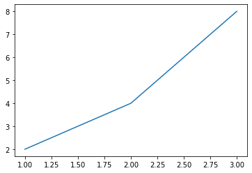

```python
plt.plot([1,2,3],[2,4,8])
plt.show()
```

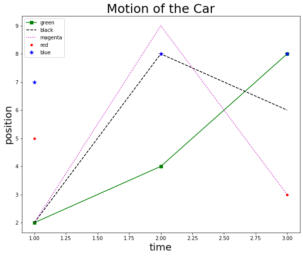

```python
plt.figure(figsize=(10,8))
plt.plot([1,2,3],[2,4,8],'gs-') #'k m g r b y c', '*.--^vo'
plt.plot([1,2,3],[2,8,6],'k--') #'k m g r b y c', '*.--^vo'
plt.plot([1,2,3],[2,9,3],'m:') #'k m g r b y c', '*.--^vo'
plt.plot([1,2,3],[5,8,3],'r.',ms=8) #'k m g r b y c', '*.--^vo'
plt.plot([1,2,3],[7,8,8],'b*',ms=8) #'k m g r b y c', '*.--^vo'
plt.legend(['green','black','magenta','red','blue'])
plt.xlabel('time',fontsize=20)
plt.ylabel('position',fontsize=20)
plt.title('Motion of the Car',fontsize=25)
plt.show()
```

`single_step(x)`

- if even divides `x` by 2
- else `3x+1`
- return the new number

`full_sequence(k)` given `k` should return the full sequence for the given `k`

- create empty list or a list containing `k`
- until we reach 1, do:
  - create new number using `single_step(k)`
  - put the new number in the list
- return the list

```python
pwd
```

```
'C:\\Users\\scassani\\Box\\buffalo_teaching_ubbox\\MTH337_S21'
```

Work on project until **1:30 pm**, on discord

- room 1-7: for work on `single_step()` and/or `full_sequence()`
- other rooms: working on exploration/analysis

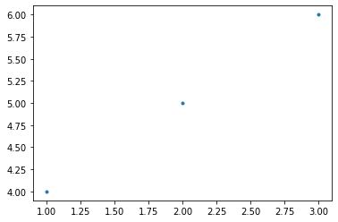

```python
plt.plot([1,2,3],[4,5,6],'.',ms=6)
```

## Mutable and non-mutable objects

```python
a=[1,2,3]
b=a
b[0]='pippo'
```

```python
print(a)
print(b)
```

```
['pippo', 2, 3]
['pippo', 2, 3]
```

```python
a=3
b=a
b+=100
print(a)
print(b)
```

```
3
103
```

- **mutable** objects (lists) can be modified without changing their address
- **non-mutable** objects cannot (int,floats,strings, booleans, tuples)

```python
a=[1,2,3] # to make a copy of a
b=a.copy()
b[0]='pippo'
print(a,b)
```

```
[1, 2, 3] ['pippo', 2, 3]
```

```python
a=[1,2,3] # to make a copy of a
b=a[:]
b[0]='pippo'
print(a,b)
```

```
[1, 2, 3] ['pippo', 2, 3]
```

**tuples**

```python
a=(1,2,3)
a[0]='pippo'
```

```
---------------------------------------------------------------------------
TypeError                                 Traceback (most recent call last)
<ipython-input-107-478222feb9c7> in <module>
      1 a=(1,2,3)
----> 2 a[0]='pippo'

TypeError: 'tuple' object does not support item assignment
```

```python
mystr='go bulls!'
```

```python
mystr[1]='a'
```

```
---------------------------------------------------------------------------
TypeError                                 Traceback (most recent call last)
<ipython-input-109-08c2911a81fe> in <module>
----> 1 mystr[1]='a'

TypeError: 'str' object does not support item assignment
```

**Ex** given a string, write some code that will change the second character to `'a'`

```python
def second(mystring):
    newstring = mystring[0] + 'a' +  mystring[2:]
    return newstring
```

```python
second('Simone')
```

```
'Samone'
```

## More on functions

```python
from math import pi
def volume(height,radius): #volume of a cylinder
    return height*radius**2 * pi
```

```python
volume(2,3) # args by postion
```

```
56.548667764616276
```

```python
volume(3,2)
```

```
37.69911184307752
```

```python
volume(radius=2,height=3) # args by keyword
```

```
37.69911184307752
```

```python
volume(2,radius=3) # mix of the two
```

```
56.548667764616276
```

```python
def p(a,b,c):
    return (a**b)/c
```

```python
p(2,3,4)
```

```
2.0
```

```python
p(2,c=4,b=3)
```

```
2.0
```

```python
p(2,3,c=4)
```

```
2.0
```

You can also give a default value to a variable

```python
def p(a,b=3,c=4):
    return (a**b)/c
```

```python
p(2)
```

```
2.0
```

```python
p(2,3)
```

```
2.0
```

```python
p(2,c=10)
```

```
0.8
```